# Terrorism and extremist violence

# Defining Terrorism

- State Department (1984): *Terrorism means premeditated, politically motivated violence perpetrated against noncombatant targets by subnational groups or clandestine agents, usually intended to influence an audience.*
- FBI: *Violent, criminal acts committed by individuals and/or groups who are inspired by, or associated with, designated foreign terrorist organizations or nations (state-sponsored).*
- Associated Press: *The calculated use of violence, especially against civilians, to create terror to disrupt and demoralize societies for political ends.*

# GTD Definition

Required:

- The incident must be intentional – the result of a conscious calculation on the part of a perpetrator.
- The incident must entail some level of violence or immediate threat of violence -including property violence, as well as violence against people.
- The perpetrators of the incidents must be sub-national actors. The database does not include acts of state terrorism.

# GTD definition (cont’d)

At least two:

- Criterion 1: The act must be aimed at attaining a political, economic, religious, or social goal.
- Criterion 2: There must be evidence of an intention to coerce, intimidate, or convey some other message to a larger audience (or audiences) than the immediate victims.
- Criterion 3: The action must be outside the context of legitimate warfare activities.

# Global Terrorism Database

- [Introduced in 2007](https://www.tandfonline.com/doi/full/10.1080/09546550701246817)
- Global coverage. Includes incidents from 1970-2020
- Project also includes terrorist group profiles

# GTD

```r
library(tidyverse)
library(readxl)
library(gtsummary)
# using 2021 update only:
gtd <- read_csv("https://raw.githubusercontent.com/Neilblund/APAN/main/gtd.csv", guess_max = 5000)%>%
    mutate(date = as.Date(paste(iyear, imonth, iday, sep = "-")))
```

# Deaths per location

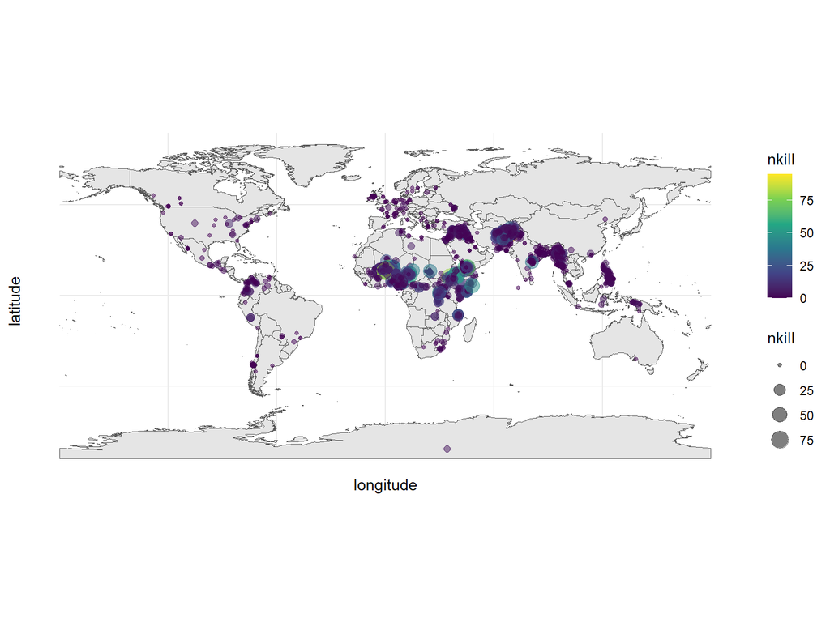

```r
#install.packages("rnaturalearth")
#install.packages("rnaturalearthdata")
#install.packages('sf')

library(sf)
library(rnaturalearth)

#install.packages("rnaturalearthhires") - if you want scale='large'
world <- ne_countries(scale = "medium", returnclass = "sf")

terror_map=ggplot(data = world) +
  geom_sf()+
  geom_point( data=gtd, aes(x=longitude, y=latitude, size=nkill, color=nkill), alpha=.5) +
  theme_minimal() +
  scale_color_viridis_c()


terror_map
```

# Get proportion by type

```r
gtd%>%
  select(attacktype1_txt)%>%
  tbl_summary(label = attacktype1_txt ~ "Attack Type", sort=~"frequency")
```

| **Characteristic** | **N = 4,960**<sup>1</sup> |
| --- | --- |
| Attack Type |  |
| Bombing/Explosion | 1,828 (37%) |
| Armed Assault | 1,292 (26%) |
| Unknown | 603 (12%) |
| Assassination | 450 (9.1%) |
| Hostage Taking (Kidnapping) | 448 (9.0%) |
| Facility/Infrastructure Attack | 281 (5.7%) |
| Unarmed Assault | 28 (0.6%) |
| Hostage Taking (Barricade Incident) | 16 (0.3%) |
| Hijacking | 14 (0.3%) |

<sup>1</sup> n (%)

# Find the incident with the highest number of fatalities

```r
gtd[which.max(gtd$nkill),]
```

[output not shown]

# Suicide attacks

```r
gtd%>%
  select(attacktype1_txt, suicide)%>%
  tbl_summary(label = attacktype1_txt ~ "Attack Type", sort=~"frequency", by="suicide")
```

| **Characteristic** | **0**, N = 4,881<sup>1</sup> | **1**, N = 79<sup>1</sup> |
| --- | --- | --- |
| Attack Type |  |  |
| Bombing/Explosion | 1,756 (36%) | 72 (91%) |
| Armed Assault | 1,289 (26%) | 3 (3.8%) |
| Unknown | 603 (12%) | 0 (0%) |
| Assassination | 446 (9.1%) | 4 (5.1%) |
| Hostage Taking (Kidnapping) | 448 (9.2%) | 0 (0%) |
| Facility/Infrastructure Attack | 281 (5.8%) | 0 (0%) |
| Unarmed Assault | 28 (0.6%) | 0 (0%) |
| Hostage Taking (Barricade Incident) | 16 (0.3%) | 0 (0%) |
| Hijacking | 14 (0.3%) | 0 (0%) |

<sup>1</sup> n (%)

# Suicide attacks

Why do groups use suicide attacks? Robert Pape argues that one of the most important motivators is simple effectiveness: suicide attacks do more damage with fewer people. Is this true?

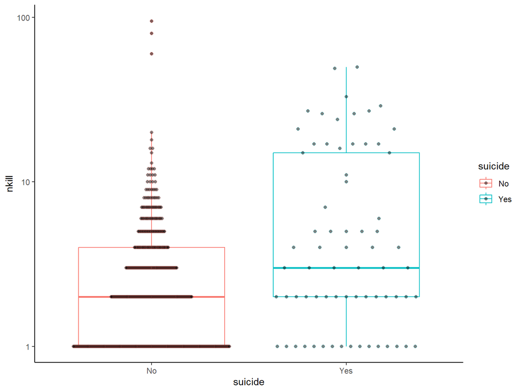

```r
library(ggbeeswarm)

gtd%>%
  mutate(suicide = factor(suicide, levels=c(0, 1), labels=c("No", "Yes")))%>%
  filter(attacktype1_txt == "Bombing/Explosion")%>%
  select(nkill, suicide)%>%
  ggplot(aes(x=suicide, y=nkill,  color=suicide)) +
  geom_boxplot(alpha=.5)+
  geom_quasirandom( alpha=.5, pch=21, fill='black', method='smiley') +
  theme_classic() +
  scale_y_log10() # log10 scale to make things a little more readable
```

What about after accounting for the number of participants?

```r
gtd%>%
  # remove missing N perps
  filter(nperps !=-99)%>%
  # reformat
  mutate(suicide = factor(suicide, levels=c(0, 1), labels=c("No", "Yes")),
         # ratio killed per perpetrator
         kill_per_perpetrator = nkill/nperps
         )%>%
  select(kill_per_perpetrator, suicide)%>%
  tbl_summary( sort=~"frequency", by="suicide")
```

| **Characteristic** | **No**, N = 506<sup>1</sup> | **Yes**, N = 54<sup>1</sup> |
| --- | --- | --- |
| kill_per_perpetrator | 0.14 (0.00, 1.00) | 1.59 (1.00, 4.75) |
| Unknown | 18 | 0 |

<sup>1</sup> Median (IQR)

# Suicide attacks

```r
gtd%>%
  # remove missing N perps
  filter(nperps !=-99)%>%
  # reformat
  mutate(suicide = factor(suicide, levels=c(0, 1), labels=c("No", "Yes")),
         # ratio killed per perpetrator
         kill_per_perpetrator = nkill/nperps
         )%>%
  select(kill_per_perpetrator, suicide)%>%
  tbl_summary( sort=~"frequency", by="suicide")
```

| **Characteristic** | **No**, N = 506<sup>1</sup> | **Yes**, N = 54<sup>1</sup> |
| --- | --- | --- |
| kill_per_perpetrator | 0.14 (0.00, 1.00) | 1.59 (1.00, 4.75) |
| Unknown | 18 | 0 |

<sup>1</sup> Median (IQR)

# Prediction

Can we predict terror attacks?

# Prediction: using trees

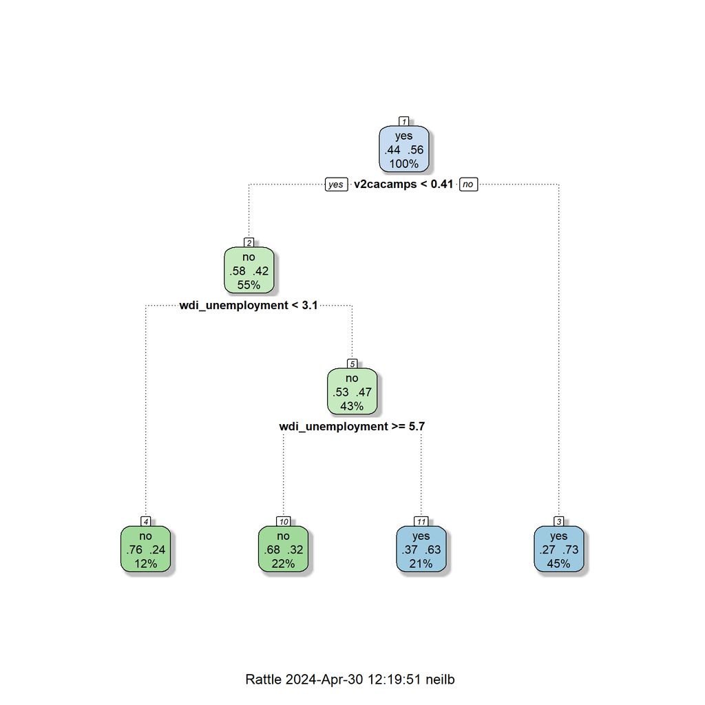

```r
library(rpart)
library(caret)
library(rattle)


gtd_2019 = read_csv('https://raw.githubusercontent.com/Neilblund/APAN/main/gtd_2019.csv')%>%
  mutate(any_attacks = factor(any_attacks))
# a simple tree based classifier
tree_model = rpart(any_attacks ~  wdi_unemployment +v2cacamps, data=gtd_2019, method='class',

                    control = rpart.control(cp = .05) # adjust this to control the complexity of the tree

                   )

# plot the result
fancyRpartPlot(tree_model)
```

# Prediction: predicting out of sample

How well does our model perform?

```r
gtd_2020 = read_csv('https://raw.githubusercontent.com/Neilblund/APAN/main/gtd_2020.csv')%>%
  mutate(any_attacks = factor(any_attacks))

predictions = predict(tree_model, type='class', newdata=gtd_2020)

table(predictions, gtd_2020$any_attacks)
```

```
##
## predictions no yes
##         no  40  24
##         yes 52  52
```

# Prediction: assessing quality

Using a confusion Matrix

Sensitivity is the number of true positives divided by true positives + false negatives (the % of countries with terror attacks that are correctly predicted)

Accuracy means what it sounds like!

Kappa gives a useful general summary statistic for how well predictions are improved relative to a guess.

```r
confusionMatrix(data = predictions, reference=gtd_2020$any_attacks)
```

```
## Confusion Matrix and Statistics
##
##           Reference
## Prediction no yes
##        no  40  24
##        yes 52  52
##
##                Accuracy : 0.5476
##                  95% CI : (0.4691, 0.6244)
##     No Information Rate : 0.5476
##     P-Value [Acc > NIR] : 0.531848
##
##                   Kappa : 0.1153
##
##  Mcnemar's Test P-Value : 0.001954
##
##             Sensitivity : 0.4348
##             Specificity : 0.6842
##          Pos Pred Value : 0.6250
##          Neg Pred Value : 0.5000
##              Prevalence : 0.5476
##          Detection Rate : 0.2381
##    Detection Prevalence : 0.3810
##       Balanced Accuracy : 0.5595
##
##        'Positive' Class : no
##
```

# Using cross validation to fit parameters

The “tuneGrid” allows us to test multiple slight variations on the same model when we cross validate, then we can automatically select the one that gives the best performance.

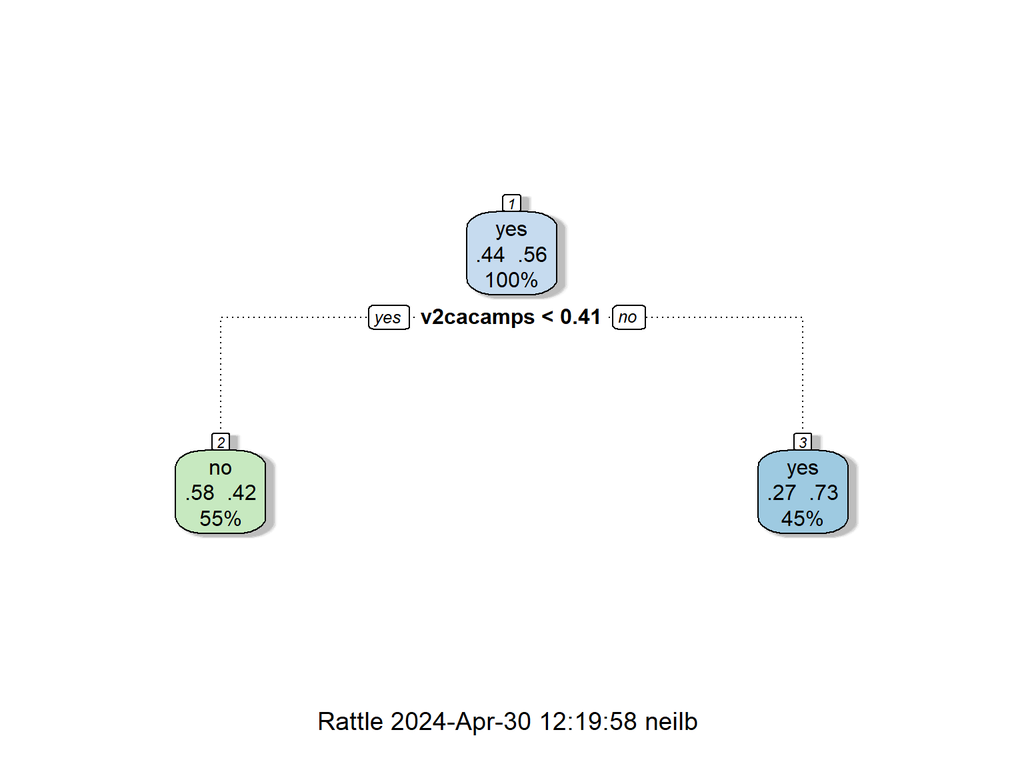

```r
tune <- data.frame(cp = seq(0, .2, by=.02))
fitControl <- trainControl(method = "LOOCV")
rf_random <- train(any_attacks ~   wdi_unemployment +v2cacamps,
                   data = gtd_2019,
                   method = 'rpart',
                   metric = 'Kappa',
                   tuneGrid = tune,


                   trControl = fitControl)


fancyRpartPlot(rf_random$finalModel)
```

```r
rf_random
```

```
## CART
##
## 168 samples
##   2 predictor
##   2 classes: 'no', 'yes'
##
## No pre-processing
## Resampling: Leave-One-Out Cross-Validation
## Summary of sample sizes: 167, 167, 167, 167, 167, 167, ...
## Resampling results across tuning parameters:
##
##   cp    Accuracy   Kappa
##   0.00  0.5892857   0.1703407
##   0.02  0.6488095   0.2781823
##   0.04  0.6547619   0.2893816
##   0.06  0.5654762   0.1247502
##   0.08  0.6428571   0.2937220
##   0.10  0.6428571   0.2937220
##   0.12  0.6428571   0.2937220
##   0.14  0.6428571   0.2937220
##   0.16  0.6428571   0.2937220
##   0.18  0.6428571   0.2937220
##   0.20  0.3273810  -0.4368756
##
## Kappa was used to select the optimal model using the largest value.
## The final value used for the model was cp = 0.18.
```

# Prediction: assessing quality

Script here: https://github.com/Neilblund/APAN/blob/main/train_test_gtd.R

Try to find a better set of predictors!

```r
predictions = predict(rf_random, type='raw', newdata=gtd_2020)
confusionMatrix(data = predictions, reference=gtd_2020$any_attacks)
```

```
## Confusion Matrix and Statistics
##
##           Reference
## Prediction no yes
##        no  59  38
##        yes 33  38
##
##                Accuracy : 0.5774
##                  95% CI : (0.4989, 0.6531)
##     No Information Rate : 0.5476
##     P-Value [Acc > NIR] : 0.2432
##
##                   Kappa : 0.1421
##
##  Mcnemar's Test P-Value : 0.6350
##
##             Sensitivity : 0.6413
##             Specificity : 0.5000
##          Pos Pred Value : 0.6082
##          Neg Pred Value : 0.5352
##              Prevalence : 0.5476
##          Detection Rate : 0.3512
##    Detection Prevalence : 0.5774
##       Balanced Accuracy : 0.5707
##
##        'Positive' Class : no
##
```

# Prediction: using a different model all together

```r
fitControl <- trainControl(method = "LOOCV", search='random')
rf_random <- train(any_attacks ~   wdi_unemployment +v2cacamps,
                   data = gtd_2019,
                   method = 'rf',
                   metric = 'kappa',


                   trControl = fitControl)



rf_random
```

```
## Random Forest
##
## 168 samples
##   2 predictor
##   2 classes: 'no', 'yes'
##
## No pre-processing
## Resampling: Leave-One-Out Cross-Validation
## Summary of sample sizes: 167, 167, 167, 167, 167, 167, ...
## Resampling results:
##
##   Accuracy   Kappa
##   0.5714286  0.1100647
##
## Tuning parameter 'mtry' was held constant at a value of 1
```

```r
predictions = predict(rf_random$finalModel, type='response', newdata=gtd_2020)
confusionMatrix(data = predictions, reference=gtd_2020$any_attacks)
```

```
## Confusion Matrix and Statistics
##
##           Reference
## Prediction no yes
##        no  50  27
##        yes 42  49
##
##                Accuracy : 0.5893
##                  95% CI : (0.5109, 0.6645)
##     No Information Rate : 0.5476
##     P-Value [Acc > NIR] : 0.15682
##
##                   Kappa : 0.185
##
##  Mcnemar's Test P-Value : 0.09191
##
##             Sensitivity : 0.5435
##             Specificity : 0.6447
##          Pos Pred Value : 0.6494
##          Neg Pred Value : 0.5385
##              Prevalence : 0.5476
##          Detection Rate : 0.2976
##    Detection Prevalence : 0.4583
##       Balanced Accuracy : 0.5941
##
##        'Positive' Class : no
##
```